# R Notebook

# 1 Dataset description

How many samples per host species ?

```r
sample_infos=read.table("../TABLES/infos2.txt", h=T, sep="\t")
n_samples_per_host = table(sample_infos$species_corrected[sample_infos$lib_type=="WGA"])
names(n_samples_per_host)[1]="A.ruf.tab" # to fit the names in other tables
names(n_samples_per_host)[9]="D.sub.obs" # to fit the names in other tables
n_samples_per_host=n_samples_per_host[-11] # remove water control
n_samples_per_host
```

```
## A.ruf.tab     C.amo     D.hyd      D.im D.kuntzei     D.mel     D.sim     D.sub
##         1         1         3         9         2         8         3         5
## D.sub.obs     D.suz       L.b       L.h     Pachy    Tricho
##         2         4         5         6         2         4
```

how many iso-female (foundresses) per species?

```r
infos_n_iso_lines=read.table("../TABLES/infos_number_of_iso_lines.txt", h=T, sep="\t")
n_isofemales_per_species=tapply(X = infos_n_iso_lines$n_iso_lines_completed, INDEX = infos_n_iso_lines$species_corrected, sum, na.rm=TRUE)
# to fit the names in the other table change two denominations
names(n_isofemales_per_species)[1]="A.ruf.tab"
names(n_isofemales_per_species)[9]="D.sub.obs"
n_isofemales_per_species
```

```
## A.ruf.tab     C.amo     D.hyd      D.im D.kuntzei     D.mel     D.sim     D.sub
##         9         1        39       116         8       230        51        62
## D.sub.obs     D.suz       L.b       L.h     Pachy    Tricho
##        19        14        89       108        30        23
```

## 1.1 WGA data

```r
data_wga=read.table("../TABLES/grouped_data_wga2.txt", h=T, sep="\t")

data_wga$virus=rownames(data_wga)
data_wga=data_wga[, c(67, 1:56)]
data_wga=data_wga[, -which(names(data_wga) == "H2O__NA__WGA")]

library('tidyr')        # Load tidyr package
# Organise the rainfall data
data_wga.long = pivot_longer(data=data_wga,
                             cols=-virus,
                             names_to="sample",
                             values_to="cov")

# Display the first 6 lines of the organised data frame
head(data_wga.long)
```

```
## # A tibble: 6 × 3
##   virus         sample                            cov
##   <chr>         <chr>                           <dbl>
## 1 LbFV_L.b n=10 A.ruf.tab_Ige_2012_Sept_WGA  0.000555
## 2 LbFV_L.b n=10 Tricho_Ige_2012_Sept_WGA     0
## 3 LbFV_L.b n=10 D.mel_Gotheron_2012_Sept_WGA 0.00201
## 4 LbFV_L.b n=10 D.sim_Gotheron_2012_Sept_WGA 0
## 5 LbFV_L.b n=10 D.sub_Gotheron_2012_Sept_WGA 0.00121
## 6 LbFV_L.b n=10 D.suz_Gotheron_2012_Sept_WGA 0.00247
```

split the sample information column

```r
liste=strsplit(data_wga.long$sample, "_")
infos=do.call(rbind.data.frame, liste)
names(infos)=c("host_species", "locality", "year", "season", "lib")
data_wga.long=data.frame(data_wga.long[,c(1,3)], infos)
head(data_wga.long)
```

```
##           virus         cov host_species locality year season lib
## 1 LbFV_L.b n=10 0.000555146    A.ruf.tab      Ige 2012   Sept WGA
## 2 LbFV_L.b n=10 0.000000000       Tricho      Ige 2012   Sept WGA
## 3 LbFV_L.b n=10 0.002006140        D.mel Gotheron 2012   Sept WGA
## 4 LbFV_L.b n=10 0.000000000        D.sim Gotheron 2012   Sept WGA
## 5 LbFV_L.b n=10 0.001211240        D.sub Gotheron 2012   Sept WGA
## 6 LbFV_L.b n=10 0.002468440        D.suz Gotheron 2012   Sept WGA
```

How many putative DNA viruses in total ?

```r
length(unique(data_wga.long$virus))
```

```
## [1] 7
```

How many potential host species ?

```r
unique(data_wga.long$host_species)
```

```
##  [1] "A.ruf.tab" "Tricho"    "D.mel"     "D.sim"     "D.sub"     "D.suz"
##  [7] "D.im"      "L.h"       "L.b"       "Pachy"     "D.sub.obs" "D.hyd"
## [13] "D.kuntzei" "C.amo"
```

Viruses per host species (min contig coverage 30%).

```r
rate_infection_wga=tapply(X = data_wga.long$cov, INDEX = list(data_wga.long$host_species, data_wga.long$virus), FUN = function(x){
  n=length(x)
  postives=sum(x>0.3)
  rate=postives/n
  return(rate)
  })
```

plot heatmap of “prevalence”

```r
 # heatmaps
library(ComplexHeatmap)
library(circlize)
col_fun = circlize::colorRamp2(c(0, 1), c("white", "black"))
col_fun(seq(-3, 3))
```

```
## [1] "#FFFFFFFF" "#FFFFFFFF" "#FFFFFFFF" "#FFFFFFFF" "#000000FF" "#000000FF"
## [7] "#000000FF"
```

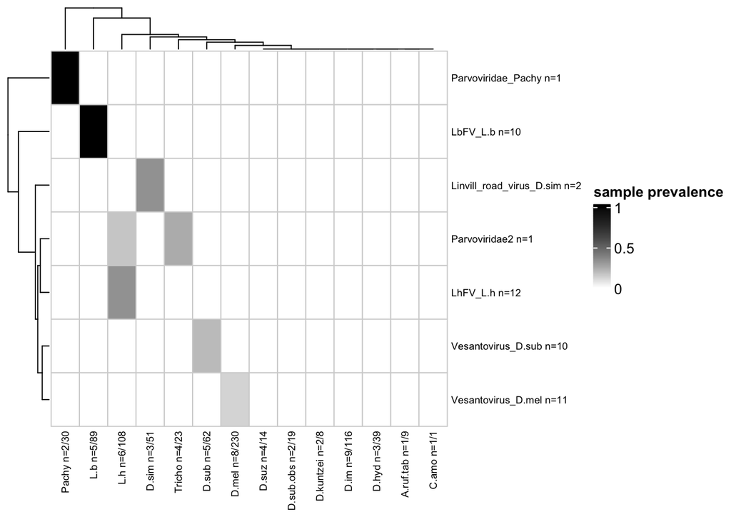

```r
t=t(rate_infection_wga)

# add the number of pooled samples per species and number of isofemale lines
colnames(t)=paste0(colnames(t),
                   " n=", n_samples_per_host,
                   "/", n_isofemales_per_species[match(names(n_isofemales_per_species), colnames(t))])

Heatmap(t, row_names_gp  = gpar(fontsize = 7),
        col = col_fun, name="sample prevalence",column_names_gp = gpar(fontsize=7),
        border = FALSE, rect_gp = gpar(col = "lightgrey"))
```

```r
dev.copy2pdf(file="../figures/heatmap_prevalence_WGA.pdf")
```

## 1.2 WTA data

```r
data_wta=read.table("../TABLES/grouped_data_wta2.txt", h=T, sep="\t")

data_wta$virus=rownames(data_wta)
data_wta=data_wta[, c(67, 1:55)]

library('tidyr')        # Load tidyr package
# Organise the rainfall data
data_wta.long = pivot_longer(data=data_wta,
                             cols=-virus,
                             names_to="sample",
                             values_to="cov")

# Display the first 6 lines of the organised data frame
head(data_wta.long)
```

```
## # A tibble: 6 × 3
##   virus                      sample                         cov
##   <chr>                      <chr>                        <dbl>
## 1 Bloomfield_virus_D.mel n=3 D.mel_Ige_2011_Juin_WTA          0
## 2 Bloomfield_virus_D.mel n=3 D.im_Ige_2011_Juin_WTA           0
## 3 Bloomfield_virus_D.mel n=3 D.sub.obs_Ige_2011_Juin_WTA      0
## 4 Bloomfield_virus_D.mel n=3 L.h_Ige_2011_Juin_WTA            0
## 5 Bloomfield_virus_D.mel n=3 D.mel_Gotheron_2011_Juin_WTA     0
## 6 Bloomfield_virus_D.mel n=3 D.im_Gotheron_2011_Juin_WTA      0
```

split the sample information column

```r
liste=strsplit(data_wta.long$sample, "_")
infos=do.call(rbind.data.frame, liste)
names(infos)=c("host_species", "locality", "year", "season", "lib")
data_wta.long=data.frame(data_wta.long[,c(1,3)], infos)
head(data_wta.long)
```

```
##                        virus cov host_species locality year season lib
## 1 Bloomfield_virus_D.mel n=3   0        D.mel      Ige 2011   Juin WTA
## 2 Bloomfield_virus_D.mel n=3   0         D.im      Ige 2011   Juin WTA
## 3 Bloomfield_virus_D.mel n=3   0    D.sub.obs      Ige 2011   Juin WTA
## 4 Bloomfield_virus_D.mel n=3   0          L.h      Ige 2011   Juin WTA
## 5 Bloomfield_virus_D.mel n=3   0        D.mel Gotheron 2011   Juin WTA
## 6 Bloomfield_virus_D.mel n=3   0         D.im Gotheron 2011   Juin WTA
```

How many putative RNA viruses in total ?

```r
length(unique(data_wta.long$virus))
```

```
## [1] 46
```

How many potential host species ?

```r
unique(data_wta.long$host_species)
```

```
##  [1] "D.mel"     "D.im"      "D.sub.obs" "L.h"       "D.hyd"     "D.suz"
##  [7] "L.b"       "D.sim"     "D.kuntzei" "Tricho"    "Pachy"     "D.sub"
## [13] "C.amo"     "A.ruf.tab"
```

Viruses per host species (min contig coverage 30%).

```r
rate_infection_wta=tapply(X = data_wta.long$cov, INDEX = list(data_wta.long$host_species, data_wta.long$virus), FUN = function(x){
  n=length(x)
  postives=sum(x>0.3)
  rate=postives/n
  return(rate)
  })
```

plot heatmap of “prevalence”

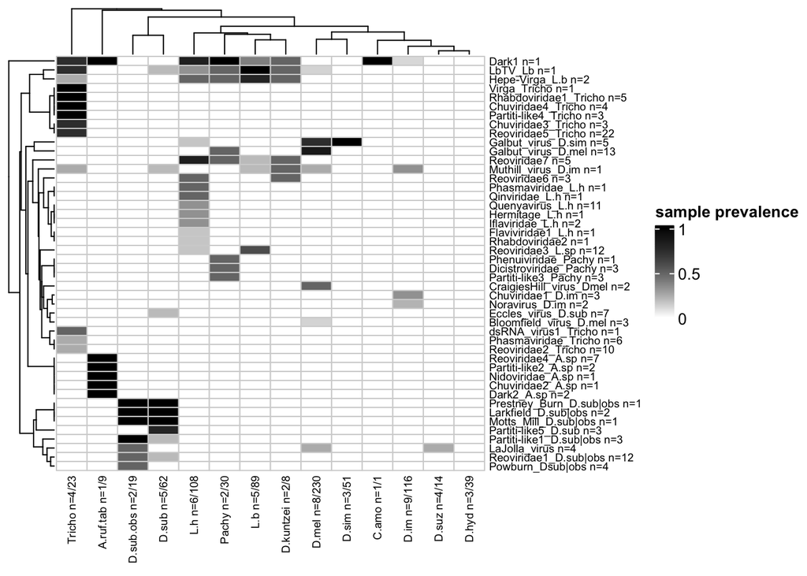

```r
 # heatmaps
col_fun = circlize::colorRamp2(c(0, 1), c("white", "black"))

t=t(rate_infection_wta)

# add the number of pooled samples per species and number of isofemale lines
colnames(t)=paste0(colnames(t),
                   " n=", n_samples_per_host,
                   "/", n_isofemales_per_species[match(names(n_isofemales_per_species), colnames(t))])

Heatmap(t, row_names_gp  = gpar(fontsize = 7),
        col = col_fun, name="sample prevalence",column_names_gp = gpar(fontsize=7),
        border = FALSE, rect_gp = gpar(col = "lightgrey"))
```

```r
dev.copy2pdf(file="../figures/heatmap_prevalence_WTA.pdf")
```

Number of virus infection per host species :

```r
DNA_virus_infection=apply(rate_infection_wga, MARGIN = 1, FUN = function(x) {
  return(sum(x>0))
  })
DNA_virus_infection
```

```
## A.ruf.tab     C.amo     D.hyd      D.im D.kuntzei     D.mel     D.sim     D.sub
##         0         0         0         0         0         1         1         1
## D.sub.obs     D.suz       L.b       L.h     Pachy    Tricho
##         0         0         1         2         1         1
```

```r
RNA_virus_infection=apply(rate_infection_wta, MARGIN = 1, FUN = function(x) {
  return(sum(x>0))
  })
RNA_virus_infection
```

```
## A.ruf.tab     C.amo     D.hyd      D.im D.kuntzei     D.mel     D.sim     D.sub
##         6         1         0         4         6         7         1         9
## D.sub.obs     D.suz       L.b       L.h     Pachy    Tricho
##         7         1         6        14         8        13
```

## 1.3 Global Heatmap for WGA and WTA datasets

plot heatmap of “prevalence”

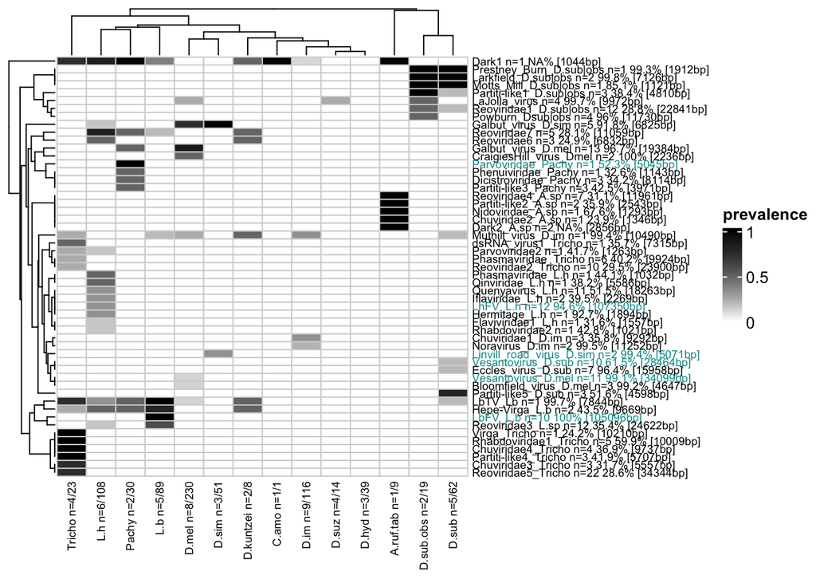

```r
grouping_info=read.table("../TABLES/summary_table.txt", h=T, sep="\t")
# ambidensovirus 2 is in fact a subset of ambidensovirus 1 (contig_18555 is included into contig_15192)
#grouping_info=grouping_info[-which(grouping_info$virus_name=="Ambidensovirus2 n=2"),]
#rate_infection_wga=rate_infection_wga[,-which(colnames(rate_infection_wga) == "Ambidensovirus2 n=2")]

# collect information on sequences (percentage identity...)
infos_names_wga=read.table("../TABLES/grouped_data_wga2.txt", h=T, sep="\t")
infos_names_wta=read.table("../TABLES/grouped_data_wta2.txt", h=T, sep="\t")
infos_names=rbind(infos_names_wta[,c("pident", "seqs_length" ,"ncontigs")], infos_names_wga[,c("pident", "seqs_length" ,"ncontigs")])

grouping_info$virus_name2=unlist(lapply(strsplit(grouping_info$virus_name, " "), FUN = function(x){return(x[[1]])}))

# add genomic structure info
grouping_info$genome="RNA"
# replace RNA by DNA for the 7 DNA viruses
names=read.table("../TABLES/summary_table.txt", h=TRUE, sep="\t")

DNA_viruses=c("Vesantovirus_D.sub",
"Vesantovirus_D.mel",
"LbFV_L.b",
"LhFV_L.h",
"Parvoviridae_Pachy",
"Parvoviridae_Tricho/L.h",
"Linvill_road_virus_D.sim")
DNA_viruses_full=list()
for (i in 1:length(DNA_viruses)){
  DNA_viruses_full[i]=grep(DNA_viruses[i], x = names$virus_name, value = TRUE)[1]
}
DNA_viruses_full=unlist(DNA_viruses_full)

grouping_info$genome[which(grouping_info$virus_name %in% DNA_viruses_full)] = "DNA"



# heatmaps
col_fun = circlize::colorRamp2(c(0, 1), c("white", "black"))


t1=t(rate_infection_wga)
t2=t(rate_infection_wta)
t=rbind(t1,t2)

# add the number of pooled samples per species and number of isofemale lines
colnames(t)=paste0(colnames(t),
                   " n=", n_samples_per_host,
                   "/", n_isofemales_per_species[match(names(n_isofemales_per_species), colnames(t))])

# add genomic structure info
genome_struct=factor(grouping_info$genome[match(rownames(t), grouping_info$virus_name)])
levels(genome_struct)=c( "#009999","#000000")

# add n contigs information
rownames(t)=grouping_info$virus_name[match(rownames(t), grouping_info$virus_name)]
# add contig length sum
library(Biostrings)
wgta_contigs=c(readDNAStringSet("../sequences/wta_final_contigs_with_unassigned.fa"),
               readDNAStringSet("../sequences/wga_final_contigs_with_unassigned.fa"))
wgta_contigs=wgta_contigs[!duplicated(wgta_contigs)]
dwgta=data.frame(cbind(names(wgta_contigs), width(wgta_contigs)))
names(dwgta)=c("contig_name", "length")
grouping_info2=merge(grouping_info, dwgta, all.x=TRUE, all.y=FALSE)
sum_contig_length=tapply(as.numeric(grouping_info2$length), INDEX = grouping_info2$virus_name, FUN = sum)
t3=data.frame(names(sum_contig_length), sum_contig_length)
t4=merge(t3, infos_names, by="row.names")
t4$pident=round(t4$pident*100,digits = 1) # round percentages

t4$new_names=paste0(t4$names.sum_contig_length.," ",t4$pident , "% [",t4$sum_contig_length, "bp]")

rownames(t)=t4[match(rownames(t), t4$Row.names),"new_names"]



Heatmap(t, row_names_gp  = gpar(fontsize = 7, col = as.character(genome_struct)),
        col = col_fun, name="prevalence",column_names_gp = gpar(fontsize=7),
        border = FALSE, rect_gp = gpar(col = "lightgrey"))
```

```r
dev.copy2pdf(file="../figures/heatmap_prevalence_both.pdf", width = 6, height = 8)
```

## 1.4 Test of the difference hosts / parasitoids

```r
tab=t(cbind(DNA_virus_infection, RNA_virus_infection))
# reorder
tab=tab[, c(2:10, 1, 11:14)]
#tab=tab[,order(apply(tab, 2, sum), decreasing = FALSE)]

# add number of samples to the names
for (i in 1:dim(tab)[2]){
  colnames(tab)[i] = grep(pattern = colnames(tab)[i], x = colnames(t), value = TRUE)
}
tab
```

```
##                     C.amo n=1/1 D.hyd n=3/39 D.im n=9/116 D.kuntzei n=2/8
## DNA_virus_infection           0            0            0               0
## RNA_virus_infection           1            0            4               6
##                     D.mel n=8/230 D.sim n=3/51 D.sub n=5/62 D.sub.obs n=2/19
## DNA_virus_infection             1            1            1                0
## RNA_virus_infection             7            1            9                7
##                     D.suz n=4/14 A.ruf.tab n=1/9 L.b n=5/89 L.h n=6/108
## DNA_virus_infection            0               0          1           2
## RNA_virus_infection            1               6          6          14
##                     Pachy n=2/30 Tricho n=4/23
## DNA_virus_infection            1             1
## RNA_virus_infection            8            13
```

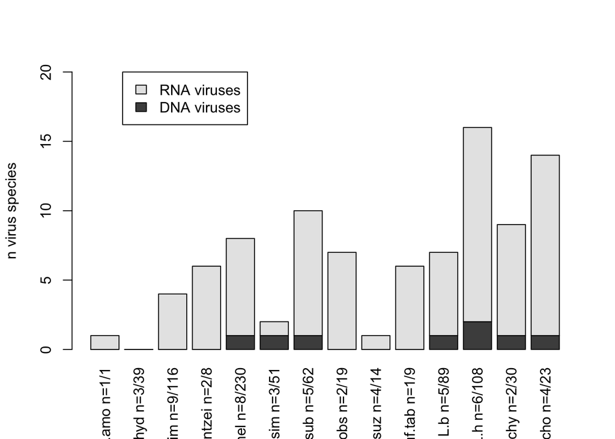

```r
bp=barplot(tab,las=3, ylab="n virus species", legend = c("DNA viruses", "RNA viruses"), args.legend = list(x = "topleft", inset=c(0.1,0)), ylim=c(0,20))
```

```r
pdf(file = "../figures/N_virus_species.pdf", width = 8, height = 6)
par(mar = c(8, 5, 2, 2)) # Set the margin on all sides
barplot(tab,las=3, ylab="n virus species", legend = c("DNA viruses", "RNA viruses"), args.legend = list(x = "topleft", inset=c(0.1,0)), ylim=c(0,20))
abline(v=mean(bp[9:10]), lty=9)
text(bp[7], y = 19, "Hosts", cex=2)
text(bp[12], y = 19, "Parasitoids", cex=2)
# add average number for hosts
segments(x0 = 0, y0 = 3.778, x1 = mean(bp[9:10]) , y1 = 3.778, lty=2, lwd = 3)
# add average number for parasitoids
segments(x0 = mean(bp[9:10]), y0 = 10.4, x1 = bp[14]+0.7 , y1 = 10.4, lty=2, lwd = 3 )
dev.off()
```

The total number of viral species per host is significantly higher in parasitoids compared to Drosophilidae:

```r
total=apply(tab, 2, sum)
total
```

```
##      C.amo n=1/1     D.hyd n=3/39     D.im n=9/116  D.kuntzei n=2/8
##                1                0                4                6
##    D.mel n=8/230     D.sim n=3/51     D.sub n=5/62 D.sub.obs n=2/19
##                8                2               10                7
##     D.suz n=4/14  A.ruf.tab n=1/9       L.b n=5/89      L.h n=6/108
##                1                6                7               16
##     Pachy n=2/30    Tricho n=4/23
##                9               14
```

Wilcoxon test :

```r
wilcox.test(x= total[c(1:9)], y = total[-c(1:9)])
```

```
##
##  Wilcoxon rank sum test with continuity correction
##
## data:  total[c(1:9)] and total[-c(1:9)]
## W = 7, p-value = 0.04479
## alternative hypothesis: true location shift is not equal to 0
```

Same conclusion after merging D.sub and D.sub+D.obs samples :

```r
total2=total[-8]
total2[7]=10 # if we merge these samples 10 viruses are found
wilcox.test(x= total2[c(1:8)], y = total2[-c(1:8)])
```

```
##
##  Wilcoxon rank sum test with continuity correction
##
## data:  total2[c(1:8)] and total2[-c(1:8)]
## W = 5.5, p-value = 0.03987
## alternative hypothesis: true location shift is not equal to 0
```

Plot the relation between number of heritable virus ientified and number of isofemale line sampled

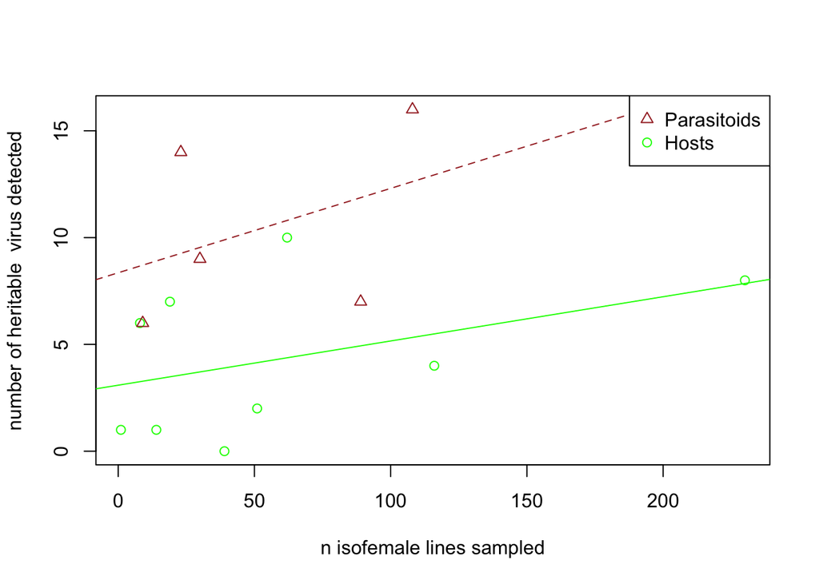

```r
n_iso=as.numeric(unlist(lapply(strsplit(names(total), "/"), FUN = function(x){return(x[2])})))
total2=rbind(total, n_iso)

lm_droso=lm(total2["total",1:9]~total2["n_iso",1:9])
lm_para=lm(total2["total",10:14]~total2["n_iso",10:14])
col_para="brown"
col_droso="green"
plot(total2["n_iso",], total2["total",], type="n", xlab="n isofemale lines sampled", ylab="number of heritable  virus detected") ; points(total2["n_iso",1:9], total2["total",1:9], pch=1, col=col_droso) ; points(total2["n_iso",10:14], total2["total",10:14], pch=2, col=col_para);abline(lm_droso, col=col_droso, lty=1); abline(lm_para, col=col_para, lty=2) ;legend("topright",c("Parasitoids", "Hosts"), col = c(col_para, col_droso), pch = c(2,1))
```

Another way of testing :

```r
n=unlist(lapply(strsplit(colnames(tab), "="), FUN=function(x){return(x[2])}))
n_samples=as.numeric(unlist(lapply(strsplit(n, "/"), FUN=function(x){return(x[1])})))
n_isofemales=as.numeric(unlist(lapply(strsplit(n, "/"), FUN=function(x){return(x[2])})))
n_viruses=apply(tab, 2, sum)
tab_other_test=data.frame((n_viruses), n_samples, n_isofemales)
names(tab_other_test)=c("n_viruses","n_samples", "n_isofemales")
tab_other_test$lifestyle="free-living"
tab_other_test$lifestyle[10:14]="parasitoid"
tab_other_test
```

```
##                  n_viruses n_samples n_isofemales   lifestyle
## C.amo n=1/1              1         1            1 free-living
## D.hyd n=3/39             0         3           39 free-living
## D.im n=9/116             4         9          116 free-living
## D.kuntzei n=2/8          6         2            8 free-living
## D.mel n=8/230            8         8          230 free-living
## D.sim n=3/51             2         3           51 free-living
## D.sub n=5/62            10         5           62 free-living
## D.sub.obs n=2/19         7         2           19 free-living
## D.suz n=4/14             1         4           14 free-living
## A.ruf.tab n=1/9          6         1            9  parasitoid
## L.b n=5/89               7         5           89  parasitoid
## L.h n=6/108             16         6          108  parasitoid
## Pachy n=2/30             9         2           30  parasitoid
## Tricho n=4/23           14         4           23  parasitoid
```

test by an anova controling for the number of pooled samples (n_samples)

```r
lm=lm(formula = tab_other_test$n_viruses ~ tab_other_test$n_samples + tab_other_test$lifestyle)
lm
```

```
##
## Call:
## lm(formula = tab_other_test$n_viruses ~ tab_other_test$n_samples +
##     tab_other_test$lifestyle)
##
## Coefficients:
##                        (Intercept)            tab_other_test$n_samples
##                             1.6764                              0.6463
## tab_other_test$lifestyleparasitoid
##                             6.3970
```

```r
anova(lm)
```

```
## Analysis of Variance Table
##
## Response: tab_other_test$n_viruses
##                          Df  Sum Sq Mean Sq F value   Pr(>F)
## tab_other_test$n_samples  1  20.781  20.781  1.5595 0.237665
## tab_other_test$lifestyle  1 130.134 130.134  9.7655 0.009664 **
## Residuals                11 146.585  13.326
## ---
## Signif. codes:  0 '***' 0.001 '**' 0.01 '*' 0.05 '.' 0.1 ' ' 1
```

same test by a glm with a poisson distribution

```r
glm=glm(formula = tab_other_test$n_viruses ~ tab_other_test$n_samples + tab_other_test$lifestyle, family="poisson")
summary(glm)
```

```
##
## Call:
## glm(formula = tab_other_test$n_viruses ~ tab_other_test$n_samples +
##     tab_other_test$lifestyle, family = "poisson")
##
## Coefficients:
##                                    Estimate Std. Error z value Pr(>|z|)
## (Intercept)                         0.97624    0.27609   3.536 0.000406 ***
## tab_other_test$n_samples            0.10881    0.04572   2.380 0.017324 *
## tab_other_test$lifestyleparasitoid  0.95379    0.21627   4.410 1.03e-05 ***
## ---
## Signif. codes:  0 '***' 0.001 '**' 0.01 '*' 0.05 '.' 0.1 ' ' 1
##
## (Dispersion parameter for poisson family taken to be 1)
##
##     Null deviance: 52.172  on 13  degrees of freedom
## Residual deviance: 29.355  on 11  degrees of freedom
## AIC: 81.423
##
## Number of Fisher Scoring iterations: 5
```

test by an anova controling for the number of foundresse females (n_iso_females)

```r
lm=lm(formula = tab_other_test$n_viruses ~ tab_other_test$n_isofemales + tab_other_test$lifestyle)
lm
```

```
##
## Call:
## lm(formula = tab_other_test$n_viruses ~ tab_other_test$n_isofemales +
##     tab_other_test$lifestyle)
##
## Coefficients:
##                        (Intercept)         tab_other_test$n_isofemales
##                             2.9172                              0.0236
## tab_other_test$lifestyleparasitoid
##                             6.2602
```

```r
anova(lm)
```

```
## Analysis of Variance Table
##
## Response: tab_other_test$n_viruses
##                             Df Sum Sq Mean Sq F value  Pr(>F)
## tab_other_test$n_isofemales  1  20.85  20.850  1.5167 0.24381
## tab_other_test$lifestyle     1 125.43 125.429  9.1238 0.01164 *
## Residuals                   11 151.22  13.747
## ---
## Signif. codes:  0 '***' 0.001 '**' 0.01 '*' 0.05 '.' 0.1 ' ' 1
```

same test by a glm with a poisson distribution

```r
glm=glm(formula = tab_other_test$n_viruses ~ tab_other_test$n_isofemales + tab_other_test$lifestyle, family="poisson")
summary(glm)
```

```
##
## Call:
## glm(formula = tab_other_test$n_viruses ~ tab_other_test$n_isofemales +
##     tab_other_test$lifestyle, family = "poisson")
##
## Coefficients:
##                                    Estimate Std. Error z value Pr(>|z|)
## (Intercept)                        1.193511   0.212349   5.621 1.90e-08 ***
## tab_other_test$n_isofemales        0.003872   0.001695   2.284   0.0224 *
## tab_other_test$lifestyleparasitoid 0.936054   0.215831   4.337 1.44e-05 ***
## ---
## Signif. codes:  0 '***' 0.001 '**' 0.01 '*' 0.05 '.' 0.1 ' ' 1
##
## (Dispersion parameter for poisson family taken to be 1)
##
##     Null deviance: 52.172  on 13  degrees of freedom
## Residual deviance: 30.117  on 11  degrees of freedom
## AIC: 82.185
##
## Number of Fisher Scoring iterations: 5
```

# 2 Identification of factors structuring viral communities

```r
rownames(data_wga)=paste0(rownames(data_wga), "_DNA")
rownames(data_wta)=paste0(rownames(data_wta), "_RNA")
dim(data_wga)
```

```
## [1]  7 56
```

```r
dim(data_wta)
```

```
## [1] 46 56
```

Combine DNA and RNA virus datasets

```r
# order columns first
data_wga=data_wga[, order(names(data_wga))]
data_wta=data_wta[, order(names(data_wta))]
names(data_wga)=sub(pattern = "_WGA", replacement = "", names(data_wga))
names(data_wta)=sub(pattern = "_WTA", replacement = "", names(data_wta))

tab=rbind(data_wga, data_wta)
# transpose
tab=t(tab)[-56,]
tab_num <- matrix(as.numeric(tab),    # Convert to numeric matrix
                  ncol = ncol(tab))
rownames(tab_num)=rownames(tab)
colnames(tab_num)=colnames(tab)
tab=tab_num
dim(tab)
```

```
## [1] 55 53
```

```r
tab[tab>=0.30]=1
tab[tab<0.30]=0
head(tab)
```

```
##                          LbFV_L.b n=10_DNA LhFV_L.h n=12_DNA
## A.ruf.tab_Ige_2012_Sept                  0                 0
## C.amo_Ige_2012_Sept                      0                 0
## D.hyd_Gotheron_2011_Juin                 0                 0
## D.hyd_Gotheron_2012_Juin                 0                 0
## D.hyd_Ige_2012_Sept                      0                 0
## D.im_Gotheron_2011_Juin                  0                 0
##                          Linvill_road_virus_D.sim n=2_DNA
## A.ruf.tab_Ige_2012_Sept                                 0
## C.amo_Ige_2012_Sept                                     0
## D.hyd_Gotheron_2011_Juin                                0
## D.hyd_Gotheron_2012_Juin                                0
## D.hyd_Ige_2012_Sept                                     0
## D.im_Gotheron_2011_Juin                                 0
##                          Parvoviridae_Pachy n=1_DNA Parvoviridae2 n=1_DNA
## A.ruf.tab_Ige_2012_Sept                           0                     0
## C.amo_Ige_2012_Sept                               0                     0
## D.hyd_Gotheron_2011_Juin                          0                     0
## D.hyd_Gotheron_2012_Juin                          0                     0
## D.hyd_Ige_2012_Sept                               0                     0
## D.im_Gotheron_2011_Juin                           0                     0
##                          Vesantovirus_D.mel n=11_DNA
## A.ruf.tab_Ige_2012_Sept                            0
## C.amo_Ige_2012_Sept                                0
## D.hyd_Gotheron_2011_Juin                           0
## D.hyd_Gotheron_2012_Juin                           0
## D.hyd_Ige_2012_Sept                                0
## D.im_Gotheron_2011_Juin                            0
##                          Vesantovirus_D.sub n=10_DNA
## A.ruf.tab_Ige_2012_Sept                            0
## C.amo_Ige_2012_Sept                                0
## D.hyd_Gotheron_2011_Juin                           0
## D.hyd_Gotheron_2012_Juin                           0
## D.hyd_Ige_2012_Sept                                0
## D.im_Gotheron_2011_Juin                            0
##                          Bloomfield_virus_D.mel n=3_RNA
## A.ruf.tab_Ige_2012_Sept                               0
## C.amo_Ige_2012_Sept                                   0
## D.hyd_Gotheron_2011_Juin                              0
## D.hyd_Gotheron_2012_Juin                              0
```

[output cut: 162 more lines]

```
## D.im_Gotheron_2011_Juin                    0                   0
##                          Rhabdoviridae1_Tricho n=5_RNA Rhabdoviridae2 n=1_RNA
## A.ruf.tab_Ige_2012_Sept                              0                      0
## C.amo_Ige_2012_Sept                                  0                      0
## D.hyd_Gotheron_2011_Juin                             0                      0
## D.hyd_Gotheron_2012_Juin                             0                      0
## D.hyd_Ige_2012_Sept                                  0                      0
## D.im_Gotheron_2011_Juin                              0                      0
##                          Virga_Tricho n=1_RNA
## A.ruf.tab_Ige_2012_Sept                     0
## C.amo_Ige_2012_Sept                         0
## D.hyd_Gotheron_2011_Juin                    0
## D.hyd_Gotheron_2012_Juin                    0
## D.hyd_Ige_2012_Sept                         0
## D.im_Gotheron_2011_Juin                     0
```

Plot virus x sample matrix

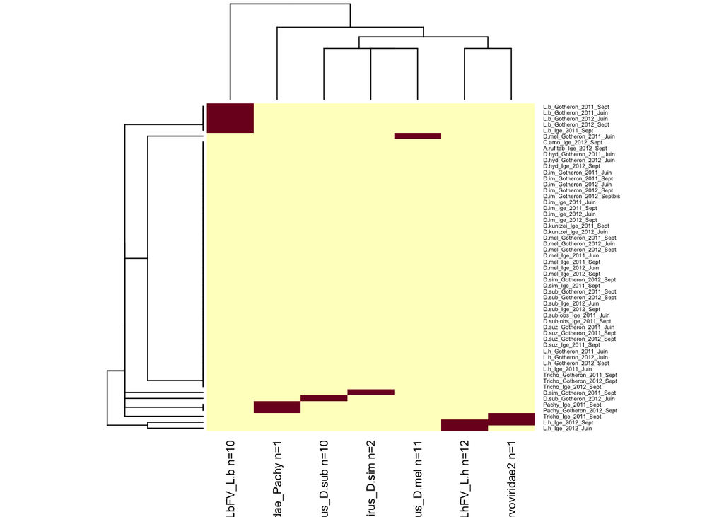

```r
tab2=as.data.frame(tab)
tab_RNA=tab2[, grep("_RNA", names(tab2))]
tab_DNA=tab2[, grep("_DNA", names(tab2))]
names(tab_DNA)=sub(pattern = "_DNA", replacement = "", names((tab_DNA)))
names(tab_RNA)=sub(pattern = "_RNA", replacement = "", names((tab_RNA)))


heatmap(as.matrix(tab_DNA), cexRow = 0.4, cexCol = 0.8, scale="none", na.rm = FALSE)
```

```r
#dev.copy2pdf(file="../figures/VirusxInsect_DNA.pdf")
```

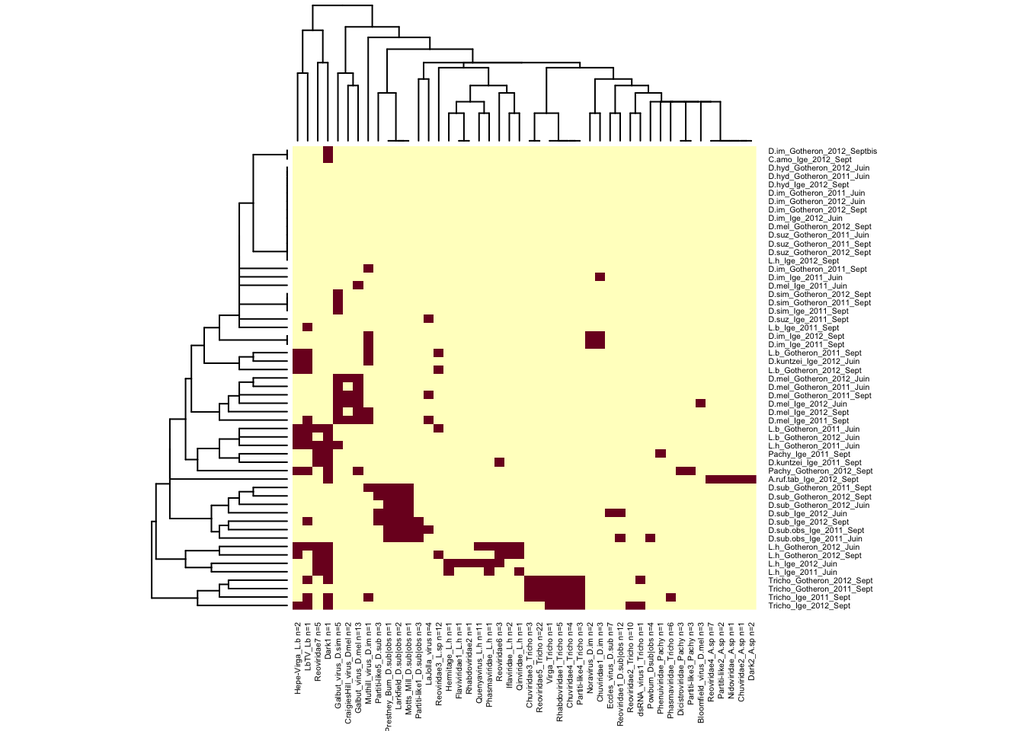

```r
heatmap(as.matrix(tab_RNA), cexRow = 0.4, cexCol = 0.4, scale="none")
```

```r
#dev.copy2pdf(file="../figures/VirusxInsect_RNA.pdf")
```

Let’s import explanatory variables : host species, time, location

```r
variables=strsplit(rownames(tab), "_")
variables=lapply(X = variables, FUN = function(x){
  species=x[1]
  location=x[2]
  year=x[3]
  season=x[4]
  res=data.frame(species, location, year, season)
  return(res)
}
  )

covariates=do.call(what = rbind.data.frame, variables)
covariates$species=as.factor(covariates$species)
head(covariates)
```

```
##     species location year season
## 1 A.ruf.tab      Ige 2012   Sept
## 2     C.amo      Ige 2012   Sept
## 3     D.hyd Gotheron 2011   Juin
## 4     D.hyd Gotheron 2012   Juin
## 5     D.hyd      Ige 2012   Sept
## 6      D.im Gotheron 2011   Juin
```

Check species levels :

```r
covariates$species
```

```
##  [1] A.ruf.tab C.amo     D.hyd     D.hyd     D.hyd     D.im      D.im
##  [8] D.im      D.im      D.im      D.im      D.im      D.im      D.im
## [15] D.kuntzei D.kuntzei D.mel     D.mel     D.mel     D.mel     D.mel
## [22] D.mel     D.mel     D.mel     D.sim     D.sim     D.sim     D.sub
## [29] D.sub     D.sub     D.sub     D.sub     D.sub.obs D.sub.obs D.suz
## [36] D.suz     D.suz     D.suz     L.b       L.b       L.b       L.b
## [43] L.b       L.h       L.h       L.h       L.h       L.h       L.h
## [50] Pachy     Pachy     Tricho    Tricho    Tricho    Tricho
## 14 Levels: A.ruf.tab C.amo D.hyd D.im D.kuntzei D.mel D.sim D.sub ... Tricho
```

Check year levels :

```r
covariates$year
```

```
##  [1] "2012" "2012" "2011" "2012" "2012" "2011" "2011" "2012" "2012" "2012"
## [11] "2011" "2011" "2012" "2012" "2011" "2012" "2011" "2011" "2012" "2012"
## [21] "2011" "2011" "2012" "2012" "2011" "2012" "2011" "2011" "2012" "2012"
## [31] "2012" "2012" "2011" "2011" "2011" "2011" "2012" "2011" "2011" "2011"
## [41] "2012" "2012" "2011" "2011" "2012" "2012" "2011" "2012" "2012" "2012"
## [51] "2011" "2011" "2012" "2011" "2012"
```

Check location levels :

```r
covariates$location
```

```
##  [1] "Ige"      "Ige"      "Gotheron" "Gotheron" "Ige"      "Gotheron"
##  [7] "Gotheron" "Gotheron" "Gotheron" "Gotheron" "Ige"      "Ige"
## [13] "Ige"      "Ige"      "Ige"      "Ige"      "Gotheron" "Gotheron"
## [19] "Gotheron" "Gotheron" "Ige"      "Ige"      "Ige"      "Ige"
## [25] "Gotheron" "Gotheron" "Ige"      "Gotheron" "Gotheron" "Gotheron"
## [31] "Ige"      "Ige"      "Ige"      "Ige"      "Gotheron" "Gotheron"
## [37] "Gotheron" "Ige"      "Gotheron" "Gotheron" "Gotheron" "Gotheron"
## [43] "Ige"      "Gotheron" "Gotheron" "Gotheron" "Ige"      "Ige"
## [49] "Ige"      "Gotheron" "Ige"      "Gotheron" "Gotheron" "Ige"
## [55] "Ige"
```

Check season levels :

```r
covariates$season
```

```
##  [1] "Sept"    "Sept"    "Juin"    "Juin"    "Sept"    "Juin"    "Sept"
##  [8] "Juin"    "Sept"    "Septbis" "Juin"    "Sept"    "Juin"    "Sept"
## [15] "Sept"    "Juin"    "Juin"    "Sept"    "Juin"    "Sept"    "Juin"
## [22] "Sept"    "Juin"    "Sept"    "Sept"    "Sept"    "Sept"    "Sept"
## [29] "Juin"    "Sept"    "Juin"    "Sept"    "Juin"    "Sept"    "Juin"
## [36] "Sept"    "Sept"    "Sept"    "Juin"    "Sept"    "Juin"    "Sept"
## [43] "Sept"    "Juin"    "Juin"    "Sept"    "Juin"    "Juin"    "Sept"
## [50] "Sept"    "Sept"    "Sept"    "Sept"    "Sept"    "Sept"
```

modify the name of a “bis” sample :

```r
covariates$season[covariates$season=="Septbis"]="Sept"
```

Run the variance partitioning :

```r
library(vegan)
varp1 <- varpart (tab, ~ species, ~ location, ~year, ~ season, data = covariates)
varp1$part
```

```
## No. of explanatory tables: 4
## Total variation (SS): 167.64
##             Variance: 3.1044
## No. of observations: 55
##
## Partition table:
##                             Df R.square Adj.R.square Testable
## [aeghklno] = X1             13  0.62710      0.50887     TRUE
## [befiklmo] = X2              1  0.01607     -0.00250     TRUE
## [cfgjlmno] = X3              1  0.01236     -0.00628     TRUE
## [dhijkmno] = X4              1  0.01990      0.00141     TRUE
## [abefghiklmno] = X1+X2      14  0.63953      0.51337     TRUE
## [acefghjklmno] = X1+X3      14  0.63681      0.50969     TRUE
## [adeghijklmno] = X1+X4      14  0.63893      0.51255     TRUE
## [bcefgijklmno] = X2+X3       2  0.02818     -0.00920     TRUE
## [bdefhijklmno] = X2+X4       2  0.03581     -0.00127     TRUE
## [cdfghijklmno] = X3+X4       2  0.03231     -0.00491     TRUE
## [abcefghijklmno] = X1+X2+X3 15  0.64860      0.51344     TRUE
## [abdefghijklmno] = X1+X2+X4 15  0.65081      0.51650     TRUE
## [acdefghijklmno] = X1+X3+X4 15  0.64896      0.51395     TRUE
## [bcdefghijklmno] = X2+X3+X4  3  0.04800     -0.00800     TRUE
## [abcdefghijklmno] = All     16  0.66023      0.51717     TRUE
## Individual fractions
## [a] = X1 | X2+X3+X4         13               0.52517     TRUE
## [b] = X2 | X1+X3+X4          1               0.00322     TRUE
## [c] = X3 | X1+X2+X4          1               0.00067     TRUE
## [d] = X4 | X1+X2+X3          1               0.00373     TRUE
## [e]                          0              -0.00631    FALSE
## [f]                          0               0.00073    FALSE
## [g]                          0              -0.00739    FALSE
## [h]                          0              -0.00252    FALSE
## [i]                          0               0.00053    FALSE
## [j]                          0              -0.00059    FALSE
## [k]                          0              -0.00036    FALSE
## [l]                          0              -0.00032    FALSE
## [m]                          0               0.00002    FALSE
## [n]                          0               0.00061    FALSE
## [o]                          0               0.00001    FALSE
## [p] = Residuals              0               0.48283    FALSE
## Controlling 2 tables X
```

[output cut: 12 more lines]

```
## Controlling 1 table X
## [aghn] = X1 | X2            13               0.51586     TRUE
## [aehk] = X1 | X3            13               0.51597     TRUE
## [aegl] = X1 | X4            13               0.51114     TRUE
## [bfim] = X2 | X1             1               0.00450     TRUE
## [beik] = X2 | X3             1              -0.00292     TRUE
## [befl] = X2 | X4             1              -0.00269     TRUE
## [cfjm] = X3 | X1             1               0.00082     TRUE
## [cgjn] = X3 | X2             1              -0.00670     TRUE
## [cfgl] = X3 | X4             1              -0.00632     TRUE
## [dijm] = X4 | X1             1               0.00368     TRUE
## [dhjn] = X4 | X2             1               0.00122     TRUE
## [dhik] = X4 | X3             1               0.00137     TRUE
## ---
## Use function 'rda' to test significance of fractions of interest
```

Visualization of the results

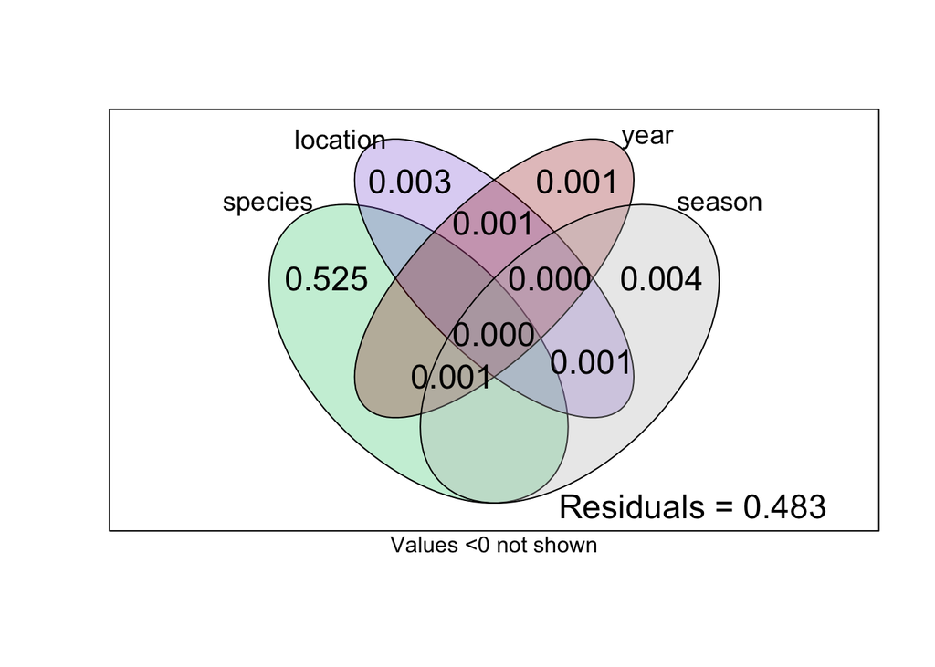

```r
plot(varp1,
     Xnames = c("species", "location", "year", "season"), # noms des matrices explicatives
     bg = c("seagreen3", "mediumpurple", "brown", "grey"), alpha = 80,
     digits = 2,
     cex = 1.5)
```

Test of the significance of each factor.

```r
# RDA of full model, gives us the fractions of [a+b+c]
rda.all <- rda(tab ~ species + location + year + season, data = covariates)
anova(rda.all)
```

```
## Permutation test for rda under reduced model
## Permutation: free
## Number of permutations: 999
##
## Model: rda(formula = tab ~ species + location + year + season, data = covariates)
##          Df Variance     F Pr(>F)
## Model    16   2.0496 4.615  0.001 ***
## Residual 38   1.0548
## ---
## Signif. codes:  0 '***' 0.001 '**' 0.01 '*' 0.05 '.' 0.1 ' ' 1
```

Individual effects

```r
rda.species <- rda(tab ~ species, data = covariates)
anova(rda.species)
```

```
## Permutation test for rda under reduced model
## Permutation: free
## Number of permutations: 999
##
## Model: rda(formula = tab ~ species, data = covariates)
##          Df Variance      F Pr(>F)
## Model    13   1.9468 5.3038  0.001 ***
## Residual 41   1.1576
## ---
## Signif. codes:  0 '***' 0.001 '**' 0.01 '*' 0.05 '.' 0.1 ' ' 1
```

```r
rda.year <- rda(tab ~ year, data = covariates)
anova(rda.year)
```

```
## Permutation test for rda under reduced model
## Permutation: free
## Number of permutations: 999
##
## Model: rda(formula = tab ~ year, data = covariates)
##          Df Variance      F Pr(>F)
## Model     1  0.03836 0.6631  0.831
## Residual 53  3.06602
```

```r
rda.season <- rda(tab ~ season, data = covariates)
anova(rda.season)
```

```
## Permutation test for rda under reduced model
## Permutation: free
## Number of permutations: 999
##
## Model: rda(formula = tab ~ season, data = covariates)
##          Df Variance      F Pr(>F)
## Model     1  0.06179 1.0763  0.338
## Residual 53  3.04259
```

```r
rda.locality <- rda(tab ~ location, data = covariates)
anova(rda.locality)
```

```
## Permutation test for rda under reduced model
## Permutation: free
## Number of permutations: 999
##
## Model: rda(formula = tab ~ location, data = covariates)
##          Df Variance      F Pr(>F)
## Model     1  0.04988 0.8654  0.579
## Residual 53  3.05450
```

The unique highly significant factor is the host species.

References :

https://sites.ualberta.ca/~ahamann/permalinks/mv690/seminars/vpart/data/